# Recreating and Modifying Time Series Plots

n.shephard@sheffield.ac.uk

2018-03-28

# Overview

A number of time-series plots were created for this work in the statistical softawre [R](https://www.r-project.org/) using the [ggplot2](https://ggplot2.tidyverse.org/) package. A selection are shown below. This document seeks to explain how these were created and how to go about recreating, modifying or adapting the plots.

## Installation

There are a number of requirements that need to be fulfilled before you can start working with the graphs…

If after having installed this package you see at any stage messages along the lines of `there is no package called 'xxxx'` then please contact the package author who will add it as a dependency to the [`closed`](https://github.com/ns-ctru/closed) package. After that has done repeat step 3 and reinstall the package and it should pull in the missing package. You can however also manually install the missing package yourself with…

```
install.packages("xxx")
```

## Usage

The [`closed`](https://github.com/ns-ctru/closed) includes a number of functions that simplify the process of doing the same task (whether thats plotting, tabulating, regression models) repeatedly across the multitude of outcomes of interest (some 54!). Of particular relevance to recreating graphs are the `closed_ts_plot()` and `closed_ts_plot_binary()` functions which generate the time-series plots. Examples of the graphs that can be generated are shown in-line below with the underlying function call along with the resulting plot. These can be used as a basis for developing or modifying the plots that are required. Knowledge of the datasets and variables (in terms of the values the variables `measure` and `submeasure` take in each dataset) are required and are detailed in the [packages README](https://github.com/ns-ctru/ctru).

Functions are written as it makes maintaining and modifying code a *lot* easier, you only have to change the underlying code in one place (the function) rather than 54 places if you wish to make the same change to all plots.

**NB** : Note that `closed_ts_plot_lsoa_binary()` takes LSOA level data files and internally derives the dichotomised High/Low summary of LSOAs that are above/below the median for the given outcome. As such it *can not* be used with the data files on the network drive as LSOA level data itself is not available anywhere other than the Virtual Machine. Instead the summary data frames where the data has already been dichotomised into High/Low can be passed to the `closed_ts_plot()` function described below.

### closed_ts_plot()

The `closed_ts_plot()` function is documented in its help page which can be accessed (after having installed the [`closed`](https://github.com/ns-ctru/closed) package as described above) by typing `?closed::closed_ts_plot` in [RStudio](https://www.rstudio.com/). The options are however described below….

| Option | Default | Description |
| --- | --- | --- |
| `df` | `ed_attendances_by_mode_site_measure` | The data frame which holds the data, must have been loaded into the R session with `load()`. |
| `sites` | `c("Bishop Auckland", "Hartlepool", "Hemel Hempstead", "Newark", "Rochdale")` | The sites to plot. |
| `indicator` | `ed attendances` | The “measure” that is to be plotted. |
| `sub.indicator` | `any` | The “sub-measure” that is to be plotted. |
| `steps` | `TRUE` | Logical indicator of whether to plot vertical lines for each step. |
| `smooth.plot` | `TRUE` | Logical indicator of whether to overlay smoothed lines (`geom_smooth()`) |
| `common.y` | `TRUE` | Generate all plots with a common y-axis range. |
| `theme` | `theme_bw()` | The [ggplot2 theme](http://ggplot2.tidyverse.org/reference/ggtheme.html) that is applied to the plot. |
| `facet` | `FALSE` | If length of `sites` > 1 whether to [facet wrap](http://ggplot2.tidyverse.org/reference/facet_wrap.html) plots. |
| `join` | `FALSE` | Logical indicator of whether to completely remove time points with spurious data so that lines are continuous. |
| `legend` | `FALSE` | Logical indicator of whether to include a legend |
| `lines` | `FALSE` | Logical indicator of whether to include a vertical line for steps |
| `exclude.control` | `FALSE` | Logical indicator of whether to exclude vertical step lines for pooled controls (default is `FALSE`, switch to `TRUE` when passing a pooled data set) |
| `xaxis.steps` | `FALSE` | Logical indicator of whether to add x-axis labels for steps. |
| `fig` | `""` | String of the figure number to apply to the title. |
| `repel` | `FALSE` | Add repelled labels to graph (deafult `FALSE`). |
| `colour` | `TRUE` | Produce colour plots or not. |
| `hide.control` | `FALSE` | Logical indicator of whether to obfuscate the control centers names |
| `systematic.outlier` | `3` | Remove systematic outliers that are the noted values away from the mean. |

What follows are examples of recreating the different types of plots, although first you *must* load the necessary dataset that you wish to plot. Key features such as dummy variables and the derivation of dichotomised High/Low change in time to Emergency Department at LSOA level data are saved in the `~/PR_CLOSED/General/stats/lib/data/*.Rda`.

```r
## Load required libraries
library(ggplot2)
## Load the data file, you will have to modify this line to either show the
## absolute path of the file you wish to load or the path relative to the
## location you are starting R/RStudio at.
load("~/work/scharr/closed/lib/data/tidied ed attendances by mode measure - site - 2016-11-21 19.54.Rda")
## To simplify the extension of this work the data frame contained in each file is _always_
## called 'df' all subsequent examples use this nomenclature meaning that all that has to be
## done to create plots for different outcomes is to modify the file that is loaded.
```

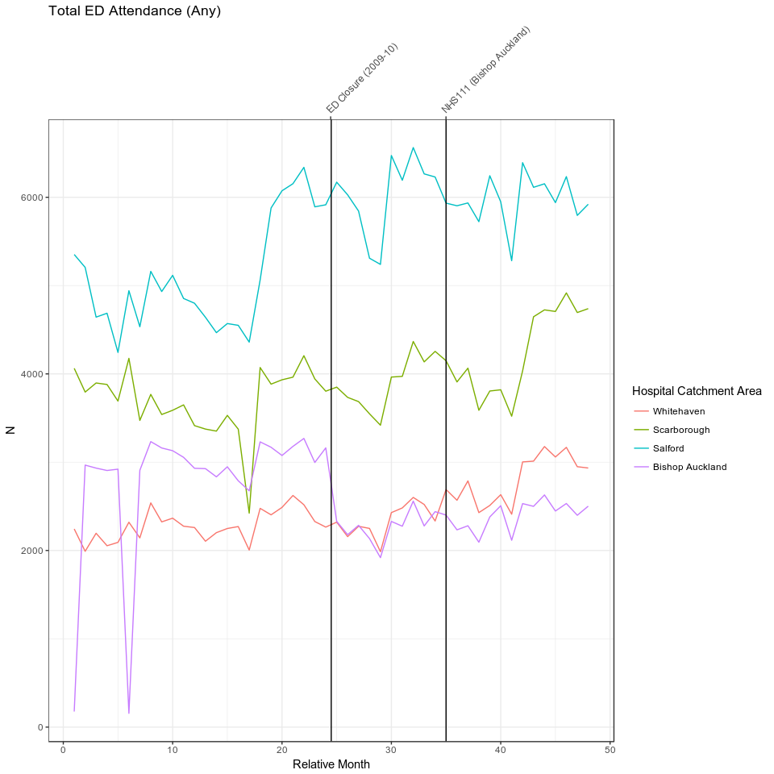

```r
## closed.html > Results > Attendance > Any > Time Series
closed_ts_plot(df            = df,
               indicator     = 'ed attendances',
               sub.indicator = 'any',
               steps         = TRUE,
               theme         = theme_bw(),
               tidy          = FALSE,
               facet         = FALSE,
               sites         = c('Bishop Auckland', 'Salford', 'Scarborough', 'Whitehaven'),
               legend        = TRUE,
               smooth        = FALSE)
```

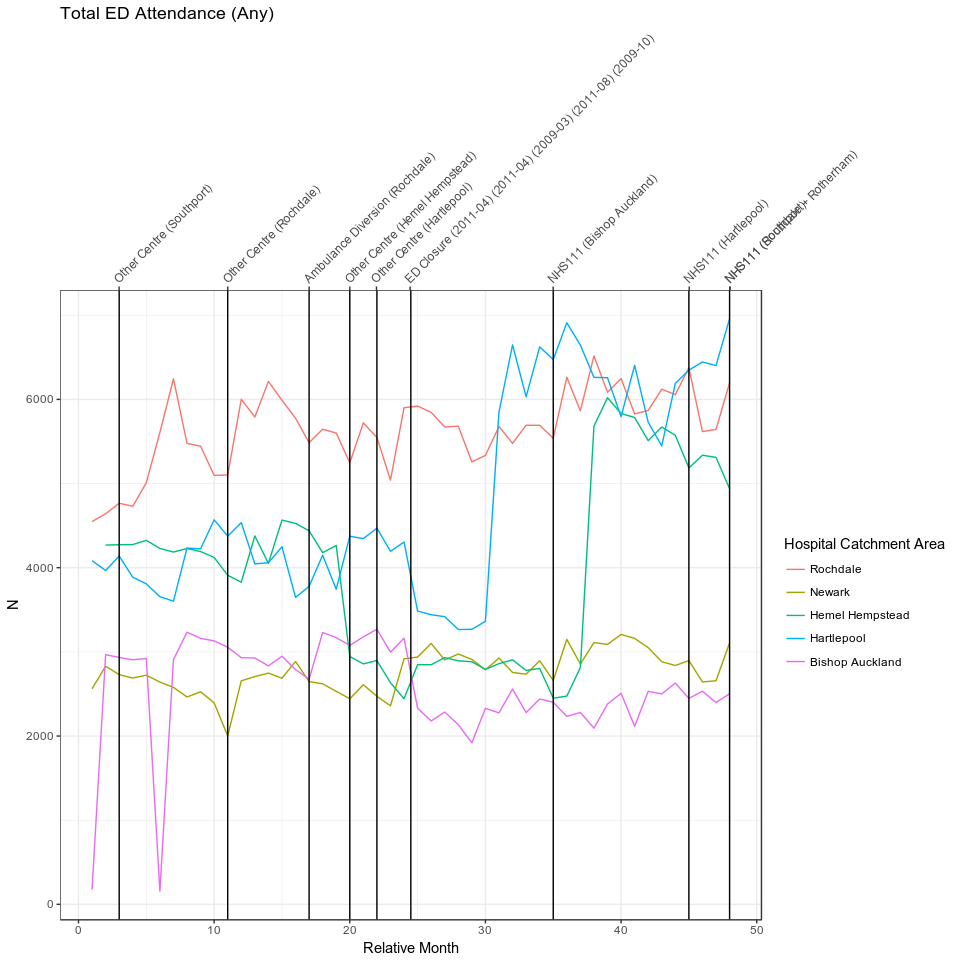

```r
## closed.html > Results > Attendance > Any > Model 1
closed_ts_plot(df            = df,
               indicator     = 'ed attendances',
               sub.indicator = 'any',
               steps         = TRUE,
               theme         = theme_bw(),
               tidy          = FALSE,
               facet         = FALSE,
               sites         = c('Bishop Auckland', 'Hartlepool', 'Hemel Hempstead', 'Newark', 'Rochdale'),
               legend        = TRUE,
               smooth        = FALSE)
```

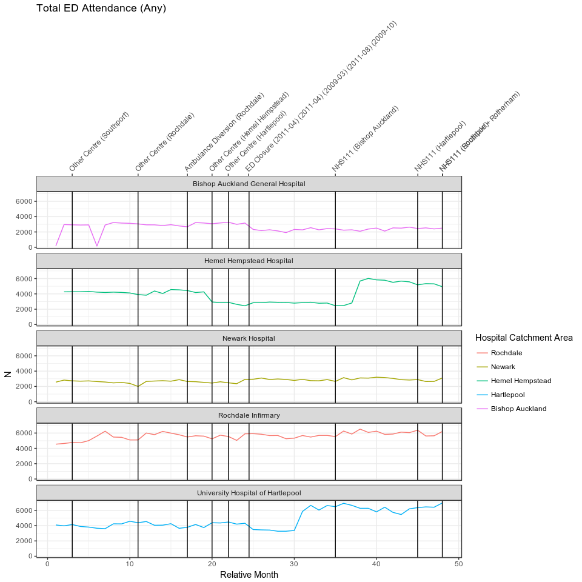

```r
## closed.html > Results > Attendance > Any > Model 2
closed_ts_plot(df            = df,
               indicator     = 'ed attendances',
               sub.indicator = 'any',
               steps         = TRUE,
               theme         = theme_bw(),
               tidy          = FALSE,
               facet         = TRUE,
               sites         = c('Bishop Auckland', 'Hartlepool', 'Hemel Hempstead', 'Newark', 'Rochdale'),
               legend        = TRUE,
               smooth        = FALSE)
```

The black and white plots generated for publications are now demonstrated….

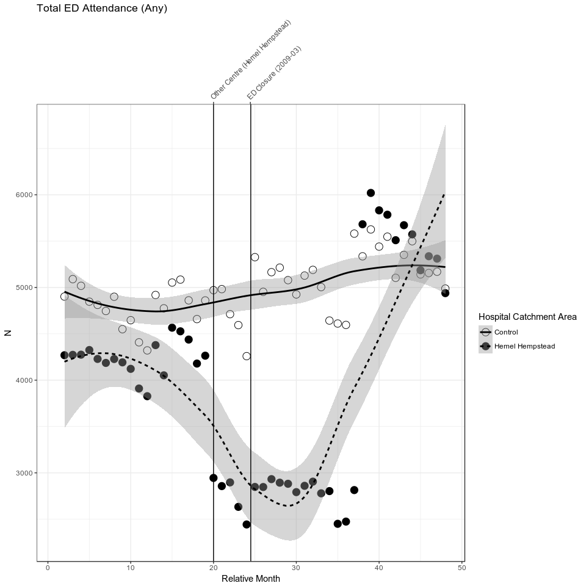

```r
## Here the options are placed in a "list" called ts-plot.opts, each has a name that reflects
## the argument to closed_ts_plot() that it is used for.
ts.plot.opts <- list()
ts.plot.opts$steps        <- TRUE
ts.plot.opts$facet        <- FALSE
ts.plot.opts$legend       <- TRUE
ts.plot.opts$tidy         <- FALSE
ts.plot.opts$colour       <- FALSE
ts.plot.opts$lines        <- FALSE
ts.plot.opts$xaxis.steps  <- TRUE
ts.plot.opts$smooth.plot  <- TRUE
ts.plot.opts$hide.control <- TRUE
## Plot the Any ED Attendances
closed_ts_plot(df            = df,
               indicator     = 'ed attendances',
               sub.indicator = 'any',
               steps         = ts.plot.opts$steps,
               theme         = theme_bw(),
               facet         = ts.plot.opts$facet,
               sites         = c('Hemel Hempstead', 'Warwick'),
               smooth.plot   = ts.plot.opts$smooth.plot,
               legend        = ts.plot.opts$legend,
               tidy          = ts.plot.opts$tidy,
               colour        = ts.plot.opts$colour,
               lines         = ts.plot.opts$lines,
               hide.control  = ts.plot.opts$hide.control,
               xaxis.steps   = ts.plot.opts$xaxis.steps)
```

Plot something other than ED Attendances, in this case Ambulance Mean Times

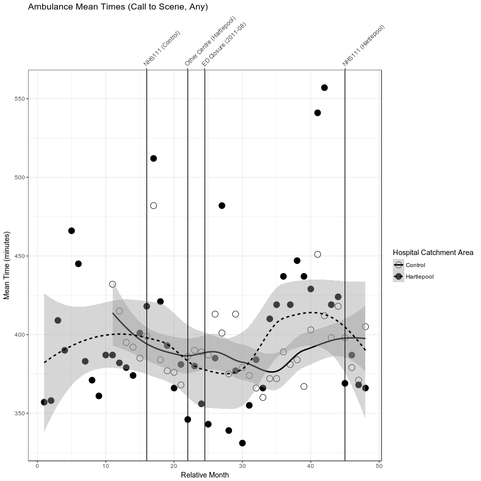

```r
## Load the ambulance mean times, note that the data frame that holds the data is
## called 'df', the same name as in the ED attendances file, on loading the old data
## frame is replaced by the new one
load("~/work/scharr/closed/lib/data/tidied ambulance mean times measure - site - 2016-11-21 20.31.Rda")
closed_ts_plot(df            = df,
               indicator     = 'ambulance mean times',
               sub.indicator = 'call to scene any',
               steps         = ts.plot.opts$steps,
               theme         = theme_bw(),
               facet         = ts.plot.opts$facet,
               sites         = c('Hartlepool', 'Grimsby'),
               smooth.plot   = ts.plot.opts$smooth.plot,
               legend        = ts.plot.opts$legend,
               tidy          = ts.plot.opts$tidy,
               colour        = ts.plot.opts$colour,
               lines         = ts.plot.opts$lines,
               hide.control  = ts.plot.opts$hide.control,
               xaxis.steps   = ts.plot.opts$xaxis.steps)
```

## From Scratch

The function `closed_ts_plot()` is simply a wrapper that takes various arguments and conditional on these adds or removes features from the plot, it also includes code which defines the various steps that are included for each site, simplifying this having to be explicitly defined each time a graph is generated. The graphs can be created from scratching using a little bit of filtering (using [dplyr](http://dplyr.tidyverse.org/)) and [ggplot2](http://ggplot2.tidyverse.org/). This examples below show how to do this (the [magrittr pipe `%>%`](http://magrittr.tidyverse.org/) is used extensively and makes code *much* more readable) and do so in a manner that demonstrates how [ggplot2](http://ggplot2.tidyverse.org/) works which in essence adds (or removes depending on the specification) features to the plot in steps (read the code and the comments which are lines beginning with `##` for more information).

[figure not shown]

```r
## Load required libraries
library(ggplot2)
## Filter the current data frame for the sites of interest
df %>%
    dplyr::filter(town %in% c("Bishop Auckland", "Hartlepool", "Hemel Hempstead", "Newark", "Rochdale")) %>%
## Filter the subset of sites for a single measure/sub.measure
    dplyr::filter(measure == "ed attendances" & sub.measure == "ambulance") %>%
## Start building the plot, first we define what we want to plot on x and y and
## how we are to colour them
    ggplot(aes(x = relative.month,
               y = value,
               colour = town)) +
## Add a geom, in this case its lines
    geom_line()
```

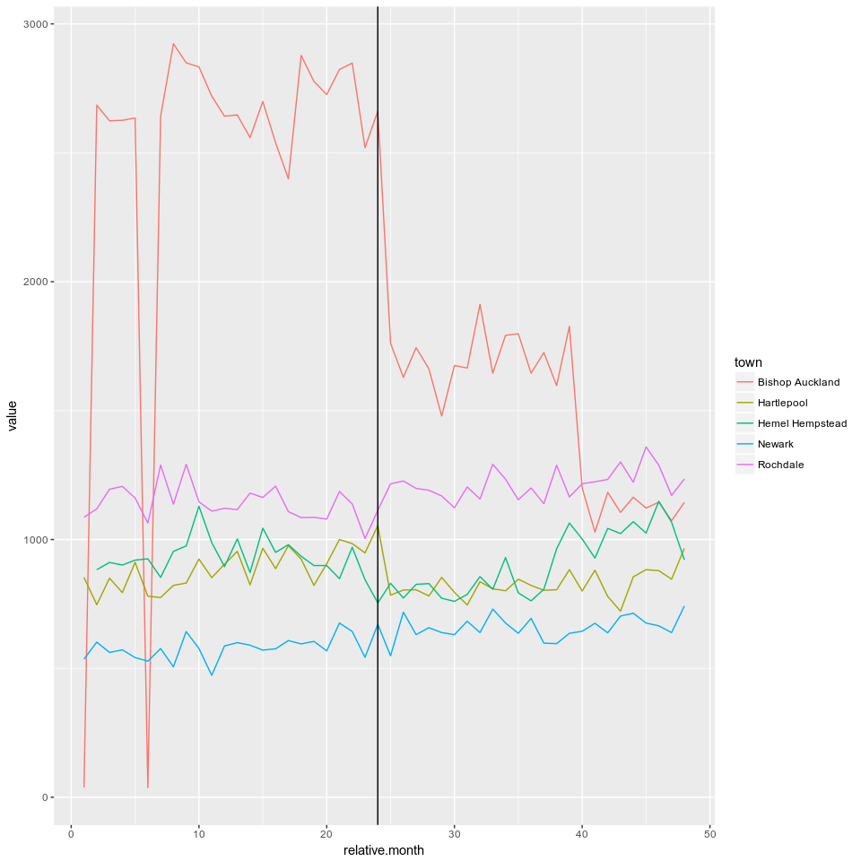

```r
## Load required libraries
library(ggplot2)
## Load the ED attendances data again
load("~/work/scharr/closed/lib/data/tidied ed attendances by mode measure - site - 2016-11-21 19.54.Rda")
## Filter the current data frame for the sites of interest
df %>%
    dplyr::filter(town %in% c("Bishop Auckland", "Hartlepool", "Hemel Hempstead", "Newark", "Rochdale")) %>%
## Filter the subset of sites for a single measure/sub.measure
    dplyr::filter(measure == "ed attendances" & sub.measure == "ambulance") %>%
## Start building the plot, first we define what we want to plot on x and y and
## how we are to colour them
    ggplot(aes(x = relative.month,
               y = value,
               colour = town)) +
## Add a geom, in this case its lines
    geom_line() +
## Add a vertical line for the mid-point where ED departments closed
    geom_vline(mapping = aes(xintercept = 24))
```

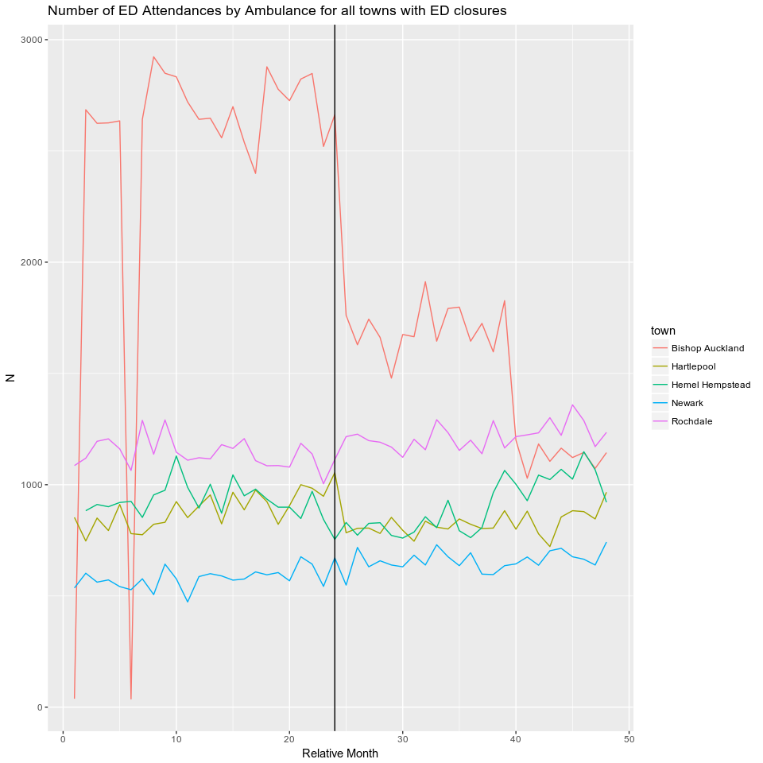

```r
## Load required libraries
library(ggplot2)
## Filter the current data frame for the sites of interest
df %>%
    dplyr::filter(town %in% c("Bishop Auckland", "Hartlepool", "Hemel Hempstead", "Newark", "Rochdale")) %>%
## Filter the subset of sites for a single measure/sub.measure
    dplyr::filter(measure == "ed attendances" & sub.measure == "ambulance") %>%
## Start building the plot, first we define what we want to plot on x and y and
## how we are to colour them
    ggplot(aes(x = relative.month,
               y = value,
               colour = town)) +
## Add a geom, in this case its lines
    geom_line() +
## Add a vertical line for the mid-point where ED departments closed
    geom_vline(mapping = aes(xintercept = 24)) +
## Add axis labels and a title
    xlab("Relative Month") +
    ylab("N") +
    ggtitle("Number of ED Attendances by Ambulance for all towns with ED closures")
```

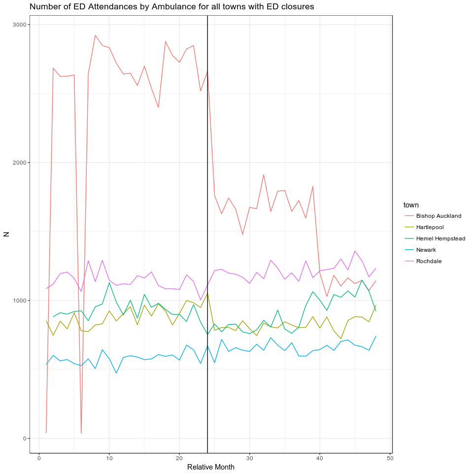

```r
## Load required libraries
library(ggplot2)
## Filter the current data frame for the sites of interest
df %>%
    dplyr::filter(town %in% c("Bishop Auckland", "Hartlepool", "Hemel Hempstead", "Newark", "Rochdale")) %>%
## Filter the subset of sites for a single measure/sub.measure
    dplyr::filter(measure == "ed attendances" & sub.measure == "ambulance") %>%
## Start building the plot, first we define what we want to plot on x and y and
## how we are to colour them
    ggplot(aes(x = relative.month,
               y = value,
               colour = town)) +
## Add a geom, in this case its lines
    geom_line() +
## Add a vertical line for the mid-point where ED departments closed
    geom_vline(mapping = aes(xintercept = 24)) +
## Add axis labels and a title
    xlab("Relative Month") +
    ylab("N") +
    ggtitle("Number of ED Attendances by Ambulance for all towns with ED closures") +
## Use the theme_bw() to get rid of the grey grid background
    theme_bw()
```